# Auckland bicycle count and rainfall

Lovdip Singh

Under Modules | Data | Bikes on Canvas you have data on the number of people counted cycling in Auckland and the amount of rain.

## Goal of study

To analyse Auckland bicycle count data as well as rainfall data in the Auckland region to determine how cycle counts change according to rainfall.

## Cleaning data - total number of cyclists counted for each day, summary of the rainfall for each day

```r
#Join all bike data
bike_files <- list.files("../data/BIKES/",pattern=".csv",full=TRUE)
bike_data <- map(bike_files,read_csv)
bike_tidy <- map(bike_data, pivot_longer, values_to ="rider_count", names_to ="counter",-Date)
allbikes <- bind_rows(bike_tidy) %>%
  separate(Date, into=c('wday', 'day', 'month', 'year')) %>%
  group_by(wday, day, month, year) %>%
  summarise(total=sum(rider_count, na.rm = T))
#Join all rain data
rain_files <- list.files("../data/rain/",pattern=".txt",full=TRUE)
rain_data <- map(rain_files, read_csv, skip=9) %>% bind_rows(.)
rain_tidy <- rain_data %>%
  separate('Date(NZST)', into=c('year', 'month', 'day'), sep=c(4,6,8)) %>%
  filter(!is.na(Station))

#Month and days to char
months <- c('Jan', 'Feb', 'Mar', 'Apr', 'May', 'Jun', 'Jul', 'Aug', 'Sep', 'Oct', 'Nov', 'Dec')
month_chr <- sprintf("%02d", 1:12)
for (i in seq(along=months)){
  pos <- which(allbikes$month == months[i])
  allbikes$month[pos] <- month_chr[i]
}

days <- as.character(1:9)
days_chr <- sprintf("%02d", 1:9)
for (i in seq(along=days)){
  pos <- which(allbikes$day == days[i])
  allbikes$day[pos] <- days_chr[i]
}


#Average rain data per data across Auckland, using Mangere and Albany data
allrain <- rain_tidy %>%
  group_by(year, month, day) %>%
  summarise(mean_rain_mm=mean(`Amount(mm)`))
#Add rain data
final_tidy <- inner_join(allbikes, allrain, by=c('year', 'month', 'day')) %>%
  arrange(year, month, day)

#Insert season column with appropriate season
final_tidy$season=as.character(NA)
seasons <- rep(c('summer', 'autumn', 'winter', 'spring'), 4, length.out=13)
pos <- c(0,
        max(which(final_tidy$day=='19' & final_tidy$month=='03' & final_tidy$year=='2016')),
        max(which(final_tidy$day=='20' & final_tidy$month=='06' & final_tidy$year=='2016')),
        max(which(final_tidy$day=='22' & final_tidy$month=='09' & final_tidy$year=='2016')),
        max(which(final_tidy$day=='20' & final_tidy$month=='12' & final_tidy$year=='2016')),
        max(which(final_tidy$day=='19' & final_tidy$month=='03' & final_tidy$year=='2017')),
        max(which(final_tidy$day=='20' & final_tidy$month=='06' & final_tidy$year=='2017')),
        max(which(final_tidy$day=='22' & final_tidy$month=='09' & final_tidy$year=='2017')),
        max(which(final_tidy$day=='21' & final_tidy$month=='12' & final_tidy$year=='2017')),
        max(which(final_tidy$day=='20' & final_tidy$month=='03' & final_tidy$year=='2018')),
        max(which(final_tidy$day=='20' & final_tidy$month=='06' & final_tidy$year=='2018')),
        max(which(final_tidy$day=='22' & final_tidy$month=='09' & final_tidy$year=='2018')),
        max(which(final_tidy$day=='21' & final_tidy$month=='12' & final_tidy$year=='2018')),
        nrow(final_tidy))
x <- 1:13
for (elt in x){
  start <- pos[elt] + 1
  end <- pos[elt+1]
  final_tidy[start:end,7] <- seasons[elt]
}

#change date to lubridate format
final_tidy <- final_tidy %>%
  unite(date, day, month, year, sep='')
final_tidy$date <- dmy(final_tidy$date)

#Final touch ups
final_tidy$DayOfYear <- as.numeric(format(final_tidy$date, "%j"))
final_tidy$season <- factor(final_tidy$season, levels=c('autumn', 'winter', 'spring', 'summer'))
final_tidy$wday <- factor(final_tidy$wday, levels=c('Mon','Tue','Wed','Thu','Fri','Sat','Sun'))
final_tidy$year <- year(final_tidy$date)
final_tidy$year <- factor(final_tidy$year)
final_tidy
```

```
## # A tibble: 1,096 x 7
## # Groups:   wday [7]
##    wday  date       total mean_rain_mm season DayOfYear year
##    <fct> <date>     <dbl>        <dbl> <fct>      <dbl> <fct>
##  1 Fri   2016-01-01  1299      0.844   summer         1 2016
##  2 Sat   2016-01-02  1030      0.798   summer         2 2016
##  3 Sun   2016-01-03  7423      0.283   summer         3 2016
##  4 Mon   2016-01-04 11956      0.00208 summer         4 2016
##  5 Tue   2016-01-05 10167      0       summer         5 2016
##  6 Wed   2016-01-06 10387      0       summer         6 2016
##  7 Thu   2016-01-07  9573      0       summer         7 2016
##  8 Fri   2016-01-08  3535      1.52    summer         8 2016
##  9 Sat   2016-01-09  8998      0.00417 summer         9 2016
## 10 Sun   2016-01-10 10429      0       summer        10 2016
## # … with 1,086 more rows
```

## Graphs

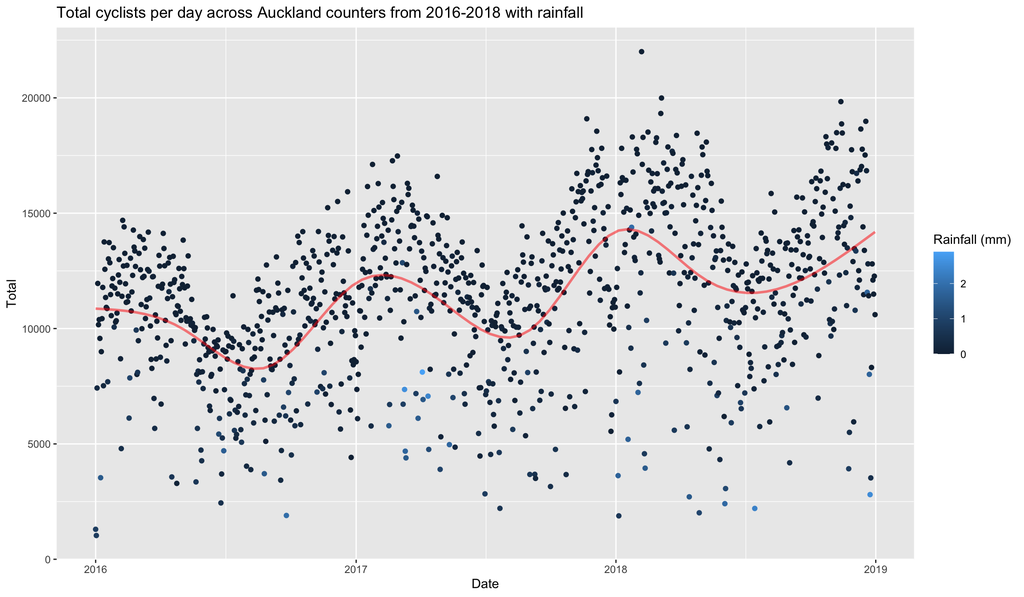

```r
(plot1 <- final_tidy %>% ggplot(aes(x=date, y=total, col=mean_rain_mm)) +
  geom_point() +
  stat_smooth(geom='line', alpha=0.5, se=FALSE, size=1, col='red') +
  labs(title = 'Total cyclists per day across Auckland counters from 2016-2018 with rainfall', x='Date', y='Total', col='Rainfall (mm)' ))
```

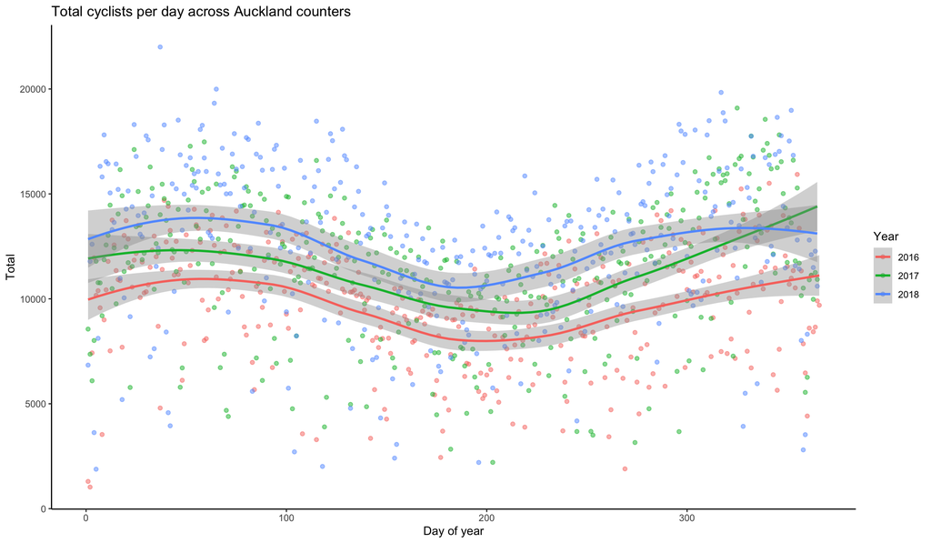

```r
(plot2 <- final_tidy %>% ggplot(aes(x=DayOfYear, y=total, group=factor(year(date)), col=factor(year(date)))) +
  geom_point(alpha=0.5) +
  geom_smooth() +
  labs(title='Total cyclists per day across Auckland counters', x='Day of year', y='Total', col='Year') +
  theme_classic())
```

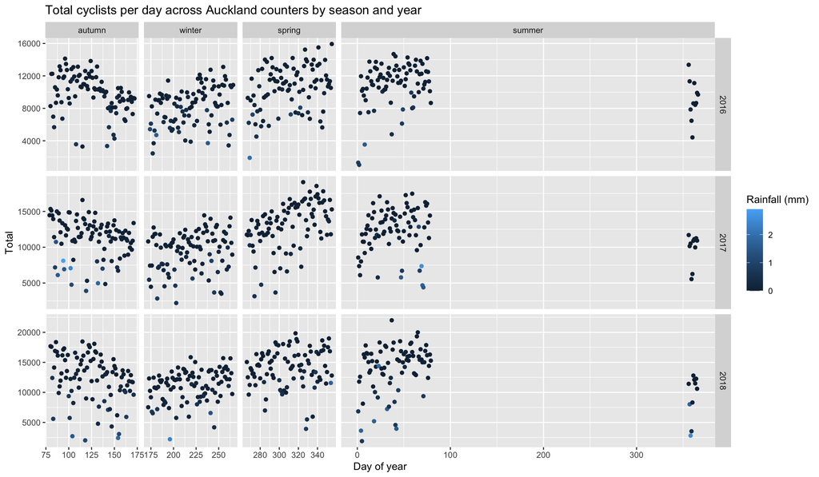

```r
plot3 <- final_tidy %>% ggplot(aes(x=DayOfYear, y=total, col=mean_rain_mm)) +
  geom_point() +
  facet_grid(year(date)~season, scale='free') +
  labs(title='Total cyclists per day across Auckland counters by season and year', x='Day of year', y='Total', col='Rainfall (mm)')


plot3_ <- ggplot_gtable(ggplot_build(plot3))
plot3_$widths[11] <- 4*plot3_$widths[11] #adjust summer width for easier comparison
grid::grid.draw(plot3_)
```

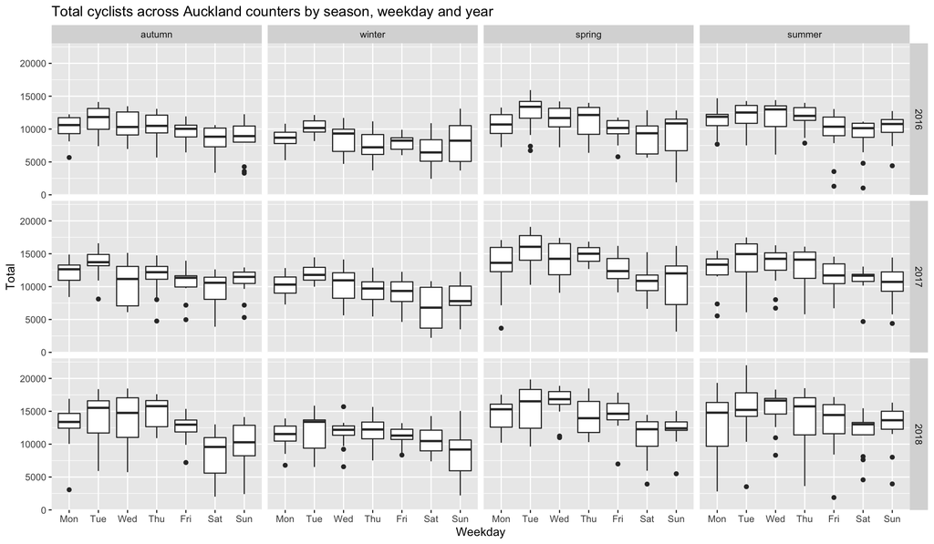

```r
(plot4 <- final_tidy %>% ggplot(aes(x=wday, y=total)) +
  geom_boxplot()) +
  facet_grid(year(date)~season) +
  labs(title='Total cyclists across Auckland counters by season, weekday and year', x='Weekday', y='Total')
```

## Simple regression model for predicting number of cyclists from year, season, day of the week, and rain.

```r
bike.fit <- lm(total~season*mean_rain_mm*year*wday, data=final_tidy)
anova(bike.fit)
```

```
## Analysis of Variance Table
##
## Response: total
##                                Df     Sum Sq    Mean Sq  F value    Pr(>F)
## season                          3 1459089301  486363100 126.7283 < 2.2e-16 ***
## mean_rain_mm                    1 3207650065 3207650065 835.7951 < 2.2e-16 ***
## year                            2 1768376413  884188206 230.3868 < 2.2e-16 ***
## wday                            6 1661904186  276984031  72.1718 < 2.2e-16 ***
## season:mean_rain_mm             3   52877103   17625701   4.5926  0.003369 **
## season:year                     6   59510503    9918417   2.5844  0.017289 *
## mean_rain_mm:year               2   87038303   43519151  11.3395 1.363e-05 ***
## season:wday                    18   64307552    3572642   0.9309  0.540394
## mean_rain_mm:wday               6   60903756   10150626   2.6449  0.015049 *
## year:wday                      12   54783450    4565288   1.1895  0.285522
## season:mean_rain_mm:year        6  325123196   54187199  14.1192 1.979e-15 ***
## season:mean_rain_mm:wday       18  208449053   11580503   3.0175 2.412e-05 ***
## season:year:wday               36  104578003    2904945   0.7569  0.849680
## mean_rain_mm:year:wday         12   93623254    7801938   2.0329  0.019050 *
## season:mean_rain_mm:year:wday  36  343736873    9548246   2.4879 4.077e-06 ***
## Residuals                     928 3561517980    3837843
## ---
## Signif. codes:  0 '***' 0.001 '**' 0.01 '*' 0.05 '.' 0.1 ' ' 1
```

```r
#drop wday interaction
bike.fit2 <- lm(total~season*mean_rain_mm*year+wday, data=final_tidy)
anova(bike.fit2)
```

```
## Analysis of Variance Table
##
## Response: total
##                            Df     Sum Sq    Mean Sq  F value    Pr(>F)
## season                      3 1459089301  486363100 116.7521 < 2.2e-16 ***
## mean_rain_mm                1 3207650065 3207650065 770.0006 < 2.2e-16 ***
## year                        2 1768376413  884188206 212.2505 < 2.2e-16 ***
## wday                        6 1661904186  276984031  66.4904 < 2.2e-16 ***
## season:mean_rain_mm         3   52877103   17625701   4.2311  0.005524 **
## season:year                 6   59510503    9918417   2.3809  0.027301 *
## mean_rain_mm:year           2   87038303   43519151  10.4468 3.213e-05 ***
## season:mean_rain_mm:year    6  376305707   62717618  15.0554 < 2.2e-16 ***
## Residuals                1066 4440717410    4165776
## ---
## Signif. codes:  0 '***' 0.001 '**' 0.01 '*' 0.05 '.' 0.1 ' ' 1
```

```r
summary(bike.fit2)
```

```
##
## Call:
## lm(formula = total ~ season * mean_rain_mm * year + wday, data = final_tidy)
##
## Residuals:
##      Min       1Q   Median       3Q      Max
## -10373.6  -1196.4    168.9   1305.7   8756.0
##
## Coefficients:
##                                    Estimate Std. Error t value Pr(>|t|)
## (Intercept)                         10995.8      282.1  38.973  < 2e-16 ***
## seasonwinter                        -1511.1      346.5  -4.361 1.42e-05 ***
## seasonspring                          592.5      337.6   1.755 0.079579 .
## seasonsummer                          727.4      333.4   2.182 0.029358 *
## mean_rain_mm                       -10657.3     1427.2  -7.467 1.70e-13 ***
## year2017                             1313.7      331.8   3.959 8.04e-05 ***
## year2018                             3183.9      343.0   9.283  < 2e-16 ***
## wdayTue                              1313.8      231.0   5.686 1.67e-08 ***
## wdayWed                               829.3      232.4   3.569 0.000375 ***
## wdayThu                               395.3      231.9   1.705 0.088567 .
## wdayFri                              -827.7      231.2  -3.580 0.000359 ***
## wdaySat                             -2188.6      231.2  -9.464  < 2e-16 ***
## wdaySun                             -1523.2      231.0  -6.593 6.78e-11 ***
## seasonwinter:mean_rain_mm            5672.2     1581.9   3.586 0.000351 ***
## seasonspring:mean_rain_mm            4803.0     1613.3   2.977 0.002976 **
## seasonsummer:mean_rain_mm            4173.3     1650.0   2.529 0.011575 *
## seasonwinter:year2017                 137.3      491.8   0.279 0.780231
## seasonspring:year2017                1541.3      474.4   3.249 0.001195 **
## seasonsummer:year2017                -113.7      465.0  -0.244 0.806941
## seasonwinter:year2018                -618.5      482.0  -1.283 0.199727
## seasonspring:year2018                 235.4      480.7   0.490 0.624341
## seasonsummer:year2018                 252.4      478.0   0.528 0.597664
## mean_rain_mm:year2017                7230.8     1483.7   4.874 1.26e-06 ***
## mean_rain_mm:year2018                2525.6     1561.2   1.618 0.106012
## seasonwinter:mean_rain_mm:year2017 -10230.4     1913.2  -5.347 1.09e-07 ***
## seasonspring:mean_rain_mm:year2017 -19433.9     2547.3  -7.629 5.22e-14 ***
## seasonsummer:mean_rain_mm:year2017  -4220.1     1773.6  -2.379 0.017518 *
## seasonwinter:mean_rain_mm:year2018  -2952.9     1835.1  -1.609 0.107887
## seasonspring:mean_rain_mm:year2018  -2814.6     1947.7  -1.445 0.148732
## seasonsummer:mean_rain_mm:year2018  -1654.7     1817.0  -0.911 0.362693
## ---
## Signif. codes:  0 '***' 0.001 '**' 0.01 '*' 0.05 '.' 0.1 ' ' 1
##
## Residual standard error: 2041 on 1066 degrees of freedom
## Multiple R-squared:  0.6614, Adjusted R-squared:  0.6521
## F-statistic: 71.79 on 29 and 1066 DF,  p-value: < 2.2e-16
```

```r
#drop year interaction for simpler model
bike.fit3 <- lm(total~season*mean_rain_mm+year+wday, data=final_tidy)
anova(bike.fit3)
```

```
## Analysis of Variance Table
##
## Response: total
##                       Df     Sum Sq    Mean Sq  F value    Pr(>F)
## season                 3 1459089301  486363100 105.8254 < 2.2e-16 ***
## mean_rain_mm           1 3207650065 3207650065 697.9373 < 2.2e-16 ***
## year                   2 1768376413  884188206 192.3863 < 2.2e-16 ***
## wday                   6 1661904186  276984031  60.2676 < 2.2e-16 ***
## season:mean_rain_mm    3   52877103   17625701   3.8351  0.009527 **
## Residuals           1080 4963571924    4595900
## ---
## Signif. codes:  0 '***' 0.001 '**' 0.01 '*' 0.05 '.' 0.1 ' ' 1
```

```r
summary(bike.fit3)
```

```
##
## Call:
## lm(formula = total ~ season * mean_rain_mm + year + wday, data = final_tidy)
##
## Residuals:
##      Min       1Q   Median       3Q      Max
## -10302.6  -1173.3    176.6   1393.0   9037.1
##
## Coefficients:
##                           Estimate Std. Error t value Pr(>|t|)
## (Intercept)                10654.9      227.8  46.764  < 2e-16 ***
## seasonwinter               -1518.1      203.6  -7.458 1.80e-13 ***
## seasonspring                1287.1      200.5   6.420 2.04e-10 ***
## seasonsummer                 962.5      198.8   4.841 1.48e-06 ***
## mean_rain_mm               -5052.1      347.4 -14.543  < 2e-16 ***
## year2017                    1669.6      159.5  10.470  < 2e-16 ***
## year2018                    3069.6      159.5  19.251  < 2e-16 ***
## wdayTue                     1402.4      242.4   5.785 9.47e-09 ***
## wdayWed                      877.5      243.4   3.605 0.000326 ***
## wdayThu                      503.5      242.6   2.075 0.038187 *
## wdayFri                     -736.7      242.1  -3.043 0.002402 **
## wdaySat                    -2243.4      242.1  -9.267  < 2e-16 ***
## wdaySun                    -1569.3      242.2  -6.479 1.40e-10 ***
## seasonwinter:mean_rain_mm   -581.7      572.2  -1.017 0.309578
## seasonspring:mean_rain_mm  -1987.5      673.0  -2.953 0.003214 **
## seasonsummer:mean_rain_mm    121.6      469.4   0.259 0.795650
## ---
## Signif. codes:  0 '***' 0.001 '**' 0.01 '*' 0.05 '.' 0.1 ' ' 1
##
## Residual standard error: 2144 on 1080 degrees of freedom
## Multiple R-squared:  0.6215, Adjusted R-squared:  0.6162
## F-statistic: 118.2 on 15 and 1080 DF,  p-value: < 2.2e-16
```

```r
#season and rain interaction explain ~1% variation make model simpler
bike.fit4 <- lm(total~season+mean_rain_mm+year+wday, data=final_tidy)
summary(bike.fit4)
```

```
##
## Call:
## lm(formula = total ~ season + mean_rain_mm + year + wday, data = final_tidy)
##
## Residuals:
##      Min       1Q   Median       3Q      Max
## -10192.5  -1160.4    217.1   1398.8   9806.8
##
## Coefficients:
##              Estimate Std. Error t value Pr(>|t|)
## (Intercept)   10672.4      225.3  47.372  < 2e-16 ***
## seasonwinter  -1612.5      181.9  -8.864  < 2e-16 ***
## seasonspring   1068.2      184.5   5.791 9.14e-09 ***
## seasonsummer    982.5      184.4   5.327 1.21e-07 ***
## mean_rain_mm  -5342.8      195.7 -27.301  < 2e-16 ***
## year2017       1716.6      159.2  10.780  < 2e-16 ***
## year2018       3102.1      159.4  19.458  < 2e-16 ***
## wdayTue        1411.3      243.3   5.800 8.67e-09 ***
## wdayWed         883.4      243.5   3.628 0.000299 ***
## wdayThu         495.4      243.4   2.035 0.042073 *
## wdayFri        -710.3      242.9  -2.924 0.003528 **
## wdaySat       -2241.8      243.0  -9.227  < 2e-16 ***
## wdaySun       -1582.4      243.0  -6.512 1.13e-10 ***
## ---
## Signif. codes:  0 '***' 0.001 '**' 0.01 '*' 0.05 '.' 0.1 ' ' 1
##
## Residual standard error: 2152 on 1083 degrees of freedom
## Multiple R-squared:  0.6175, Adjusted R-squared:  0.6132
## F-statistic: 145.7 on 12 and 1083 DF,  p-value: < 2.2e-16
```

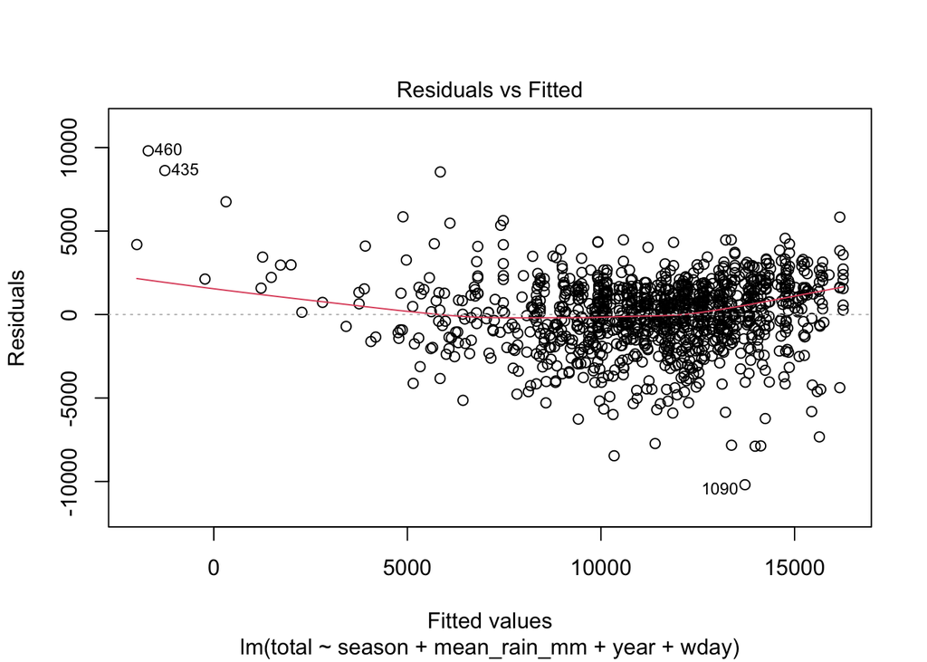

```r
plot(bike.fit4, which = 1)
```

```r
confint(bike.fit4)
```

```
##                    2.5 %     97.5 %
## (Intercept)  10230.38955 11114.4965
## seasonwinter -1969.49945 -1255.5964
## seasonspring   706.30302  1430.1567
## seasonsummer   620.60041  1344.3887
## mean_rain_mm -5726.79894 -4958.7989
## year2017      1404.10124  2029.0183
## year2018      2789.25716  3414.8915
## wdayTue        933.88325  1888.6933
## wdayWed        405.60102  1361.2511
## wdayThu         17.78209   972.9795
## wdayFri      -1186.98408  -233.6555
## wdaySat      -2718.52576 -1765.0756
## wdaySun      -2059.22836 -1105.6654
```

## Does rain have a big impact on the number of people cycling in Auckland?

Yes, the graphs suggest there are lower numbers of cyclists across Auckland when there is higher rainfall in Auckland. This is confirmed from the regression model which shows that for each mm of rainfall the number of cyclists decreases by about 5000 to 5700. This is a significant proportion of the average number of cyclists counted per weekday and across seasons and years therefore its impact is of great practical significance.